# Differential gene expression estimation using GEO data and limma Package

```r
.libPaths('~/work/rlib/')
```

```r
library(GEOquery, stringr)
```

```r
library(dplyr)
library(stringr)
library(magrittr)
library(limma, made4)
```

```r
detect_text <- function(text, pattern){
    return (any(pattern %in% (text %>% str_split("///") %>% unlist() %>% str_trim())))
}

extract_gene_ids <- function(geneids, gpl){
    tryCatch( {ret <- gpl$ID[sapply(gpl$ENTREZ_GENE_ID, detect_text,gids, USE.NAMES = FALSE)]},
             error=function(error){},
             warning=function(warning){})
    tryCatch( {ret <- gpl$ID[sapply(gpl$Entrez_Gene_ID, detect_text,gids, USE.NAMES = FALSE)]},
             error=function(error){},
             warning=function(warning){})


    return(ret)

}
```

# GSE19246

### PMID: [20688907](https://pubmed.ncbi.nlm.nih.gov/20688907/)

## Abstract

A new method for amplification and labeling of RNA is assessed that permits gene expression microarray analysis of formalin-fixed paraffin-embedded tissue (FFPET) samples. Valid biological data were obtained using gene expression microarrays of diffuse large B-cell lymphoma (DLBCL) FFPET samples. We examined 59 matched DLBCL patient samples, FFPET, and fresh/frozen. The samples contained both prognostic subgroups of DLBCL: germinal center B-cell (GCB) and activated B-cell (ABC). Fresh/frozen (FF) samples were amplified by both the traditional Eberwine oligo-dT method and a new method described herein. The matching FFPET samples were also amplified using the new method. Here we detail the comparison of results from all three datasets of matched samples. An established classification model built from previous data accurately classified these new samples. This new method provides a useful technology advance for microarray analysis of FFPET archival samples.

## Geo dataset description

### Summary

A new method for amplification and labeling of RNA is assessed that permits gene expression microarray analysis of formalin-fixed paraffin embedded tissue (i.e. FFPET) samples. Valid biological data was obtained using gene expression microarrays of diffuse large B-cell lymphoma (i.e. DLBCL) FFPET samples.

### Overall design

We examined 59 matched DLBCL patient samples, FFPET and fresh/frozen. The samples contained both prognostic subgroups of DLBCL: germinal center B-cell (i.e. GCB) and activated B-cell (ABC).  
Fresh/frozen (i.e. FF) samples were amplified by both the traditional Eberwine oligo-dT method and a new method described herein. The matching FFPET samples were also amplified using the new method.  
This study is a collaboration among Roche Molecular Diagnostics, British Columbia Cancer Agency, National Cancer Institute and Nugen Technologies (the maker of the WT-Ovation FFPET reagents).

```r
gs <- getGEO(filename = "GSE19246_series_matrix.txt.gz")
```

[output not shown]

```r
gpl_name <- levels(gs$platform_id)
```

```r
gpl <- Table(getGEO(filename = paste0(gpl_name,".soft")))
```

```r
library(plyr)
```

```r
sample_data <- ldply(gs$title %>% str_split("-"))
colnames(sample_data) <- c("type", "path", "id")
rownames(sample_data) <- rownames(pData(gs))
sample_data<- sample_data[sample_data$path != 'Unclassified',]
```

```r
head(sample_data[sample_data$type=="FFN",])
```

A data.frame: 6 × 3

|  | type <chr> | path <chr> | id <chr> |
| --- | --- | --- | --- |
| GSM476955 | FFN | ABC | D1 |
| GSM476956 | FFN | ABC | G3 |
| GSM476959 | FFN | ABC | D4 |
| GSM476961 | FFN | GCB | F5 |
| GSM476962 | FFN | GCB | D5 |
| GSM476963 | FFN | ABC | C6 |

# Creating 3 sets (N, A, P)

```r
gsn <- gs[,sampleNames(gs) %in% rownames(sample_data[sample_data$type=="FFN",])]
gsnsd <- ldply(gsn$title%>%str_split("-"))
colnames(gsnsd)<- c("type", 'path', 'id')
rownames(gsnsd)<- sampleNames(gsn)
```

```r
gsa <- gs[,sampleNames(gs) %in% rownames(sample_data[sample_data$type=="FFA",])]
gsasd <- ldply(gsa$title%>%str_split("-"))
colnames(gsasd)<- c("type", 'path', 'id')
rownames(gsasd)<- sampleNames(gsa)
```

```r
gsp <- gs[,sampleNames(gs) %in% rownames(sample_data[sample_data$type=="FPET",])]
gspsd <- ldply(gsp$title%>%str_split("-"))
colnames(gspsd)<- c("type", 'path', 'id')
rownames(gspsd)<- sampleNames(gsp)
```

# FFN

```r
library(made4)
```

```r
library(IRdisplay)
```

Full set

```
[1] "Data (original) range:  0.65 41637.65"
[1] "Data (scale) range:  -2.24 4.63"
[1] "Data scaled to range:  -2.24 3"
     Class Color
[1,] "ABC" "red"
[2,] "GCB" "blue"
```

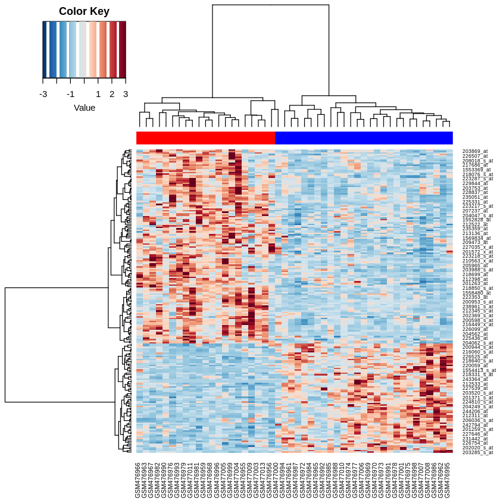

```r
gsnsd$path <- as.factor(gsnsd$path)
path <- gsnsd$path
design <- ~0+path

mm <- model.matrix(design, levels=gsnsd)

esfull <- exprs(gsn)

cm <- makeContrasts(pathABC-pathGCB, levels = colnames(mm))

fit1 <- lmFit(esfull, mm)
fit2 <- contrasts.fit(fit1, cm)
fit3 <- eBayes(fit2)
tT <- topTable(fit3, adjust="BH", number=200, lfc=1.5, p.value=0.05)
des_FFN <- rownames(tT)
display_html("<h2> Full set </h2>")
heatplot(esfull[des_FFN,], classvec = path, method = 'ward.D2')
```

# FFA

Full set

```
[1] "Data (original) range:  1.2 66840.08"
[1] "Data (scale) range:  -2.24 5.26"
[1] "Data scaled to range:  -2.24 3"
     Class Color
[1,] "ABC" "red"
[2,] "GCB" "blue"
```

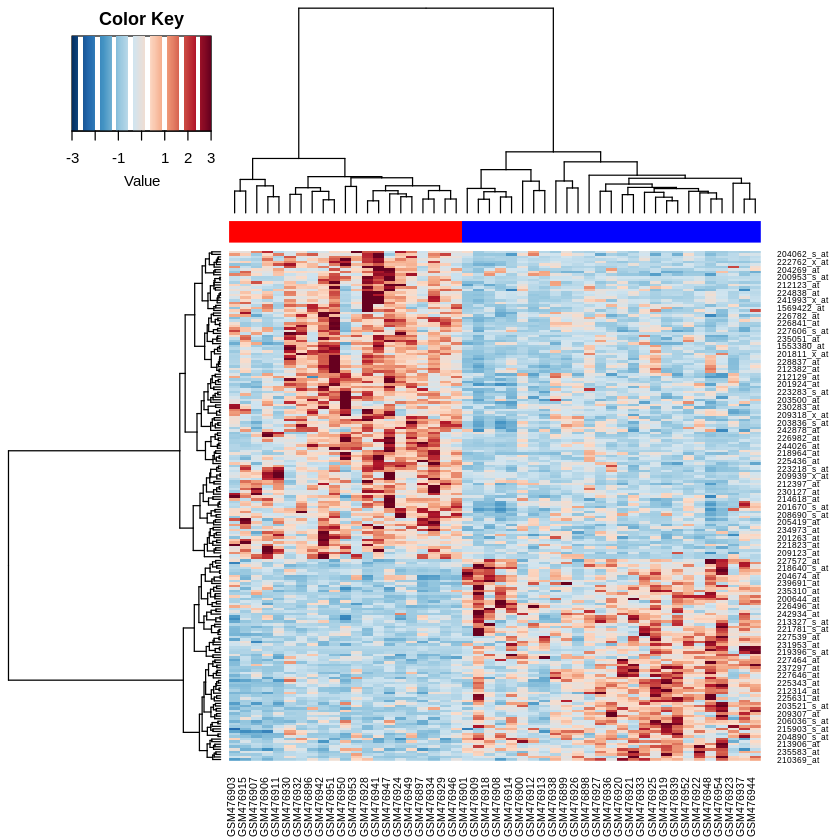

```r
gsasd$path <- as.factor(gsasd$path)
path <- gsasd$path
design <- ~0+path

mm <- model.matrix(design, levels=gsasd)

esfull <- exprs(gsa)

cm <- makeContrasts(pathABC-pathGCB, levels = colnames(mm))

fit1 <- lmFit(esfull, mm)
fit2 <- contrasts.fit(fit1, cm)
fit3 <- eBayes(fit2)
tT <- topTable(fit3, number = 200, lfc=1.5, adjust="BH", p.value=0.05)
des_ffa <- rownames(tT)
display_html("<h2> Full set </h2>")
heatplot(esfull[des_ffa,], classvec = path, method = 'ward.D2')
```

# FFPET

Full set

```
[1] "Data (original) range:  3.28 122126.53"
[1] "Data (scale) range:  -1.85 4.86"
[1] "Data scaled to range:  -1.85 3"
     Class Color
[1,] "ABC" "red"
[2,] "GCB" "blue"
```

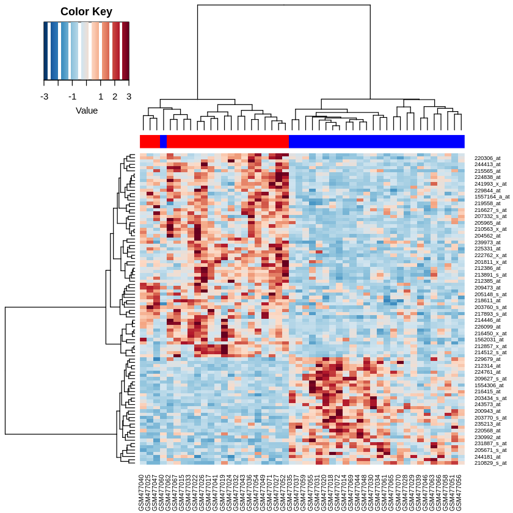

```r
gspsd$path <- as.factor(gspsd$path)
path <- gspsd$path
design <- ~0+path

mm <- model.matrix(design, levels=gspsd)

esfull <- exprs(gsp)

cm <- makeContrasts(pathABC-pathGCB, levels = colnames(mm))

fit1 <- lmFit(esfull, mm)
fit2 <- contrasts.fit(fit1, cm)
fit3 <- eBayes(fit2)
tT <- topTable(fit3, number = 200, lfc = 1.5, adjust="BH", p.value=0.05)
des_PEFT <- rownames(tT)
display_html("<h2> Full set </h2>")
heatplot(esfull[des_PEFT,], classvec = path, method = 'ward.D2')
```

```r
con <- list(FFA=des_ffa, FFN=des_FFN, FFPET=des_PEFT)
```

```r
library(eulerr)
```

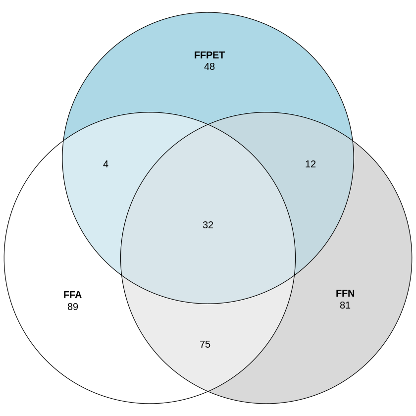

```r
plot(venn(con))
```